$\text{Michael Higgins, Sierra Wilde}$

# $$\text{Lab 2: Probability, Distributions, and Statistical Questions}$$

## Problem 1:

### A).

```python
import numpy as np
import matplotlib.pyplot as plt
import scipy as sp
from scipy import stats
from scipy import special
```

$\text{I chose to use X =0.6 and Y = 2}$

```python
mu1d = 0.6
k1d = np.arange(0,51)

ppmf1d = stats.poisson.pmf(k1d,mu1d)
```

The Poisson distribution is a discrete probability distribution that expresses the probability of a given number of events occurring in a fixed interval of time or space if these events occur with a known constant rate and independently of the time since the last event.

$$P = \frac{e^{-\mu}\mu_1^k}{k!}$$

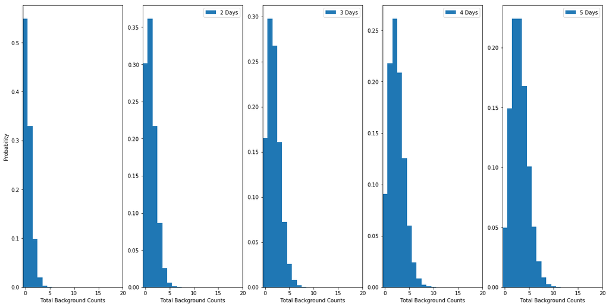

```python
fig, ax = plt.subplots(1,5,figsize=(20,10))
ppmf = ppmf1d

ax[0].bar(k1d,ppmf1d,width=1)
ax[0].set_ylabel("Probability")
ax[0].set_xlabel("Total Background Counts")
ax[0].set_xlim(-.5,20)

for j in np.arange(1,5):
    ppmf = np.convolve(ppmf,ppmf1d,mode ='full')
    ax[j].bar(np.arange(0,len(ppmf)),ppmf,width=1,label = "{0:d} Days".format(j+1))
    ax[j].set_xlim(-.5,20)
    ax[j].set_xlabel("Total Background Counts")
    ax[j].legend()
```

We can see the mean of the distrubition gets larger, but the distribution is becoming more symmetric about the mean.

### B).

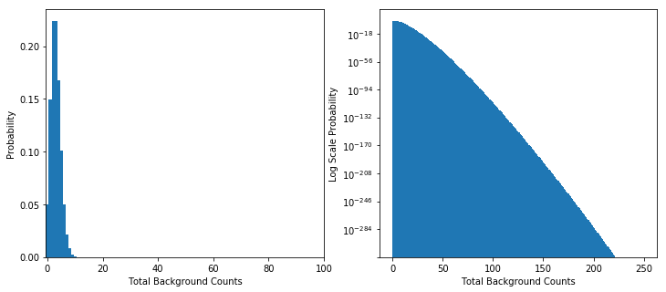

```python
ppmf = ppmf1d

for j in np.arange(1,5):
    ppmf = np.convolve(ppmf1d,ppmf,'full')

fig,ax = plt.subplots(1,2,figsize=(12,5))

ax[0].bar(np.arange(0,len(ppmf)),ppmf,width =1)
ax[0].set_xlim(-.5,100)
ax[0].set_xlabel('Total Background Counts')
ax[0].set_ylabel('Probability');

ax[1].bar(np.arange(0,len(ppmf)),ppmf,width =1)
#ax[1].set_xlim(-.5,50)
ax[1].set_xlabel('Total Background Counts')
ax[1].set_ylabel('Log Scale Probability')
ax[1].set_yscale('log');
```

The graph of the log plot of the probability looks like that of a Poisson distribution. The fact that it remained a Poisson distribution after just a few convolutions makes sense conceptually because any Poisson distributed random variable that is added to another Poisson distributed variable should maintain their quality of being Poisson except for when a large number of them are summed together because then the central limit theorem states that the pmf will approach a Guassian. This can be explained mathematically as $\Large{\sum pois(\lambda_1) +pois(\lambda_2) = \sum pois(\lambda_1 + \lambda_2)}$

$$ = \sum \left( \frac{e^{-\lambda_1}\lambda_1^x}{x!} + \frac{e^{-\lambda_2}\lambda_2^y}{y!} \right)$$

$$= e^{-(\lambda_1 + \lambda_2)}\sum \left( \frac{\lambda_1^x}{x!} + \frac{\lambda_2^y}{y!} \right)$$

$$ \text{in our case x = y = k} $$

$$\text{New Poisson} = \frac{e^{-(\lambda_1 + \lambda_2)}(\lambda_1 + \lambda_2)^k}{k!}$$

This new added Poisson has the same function as the original Poisson $\frac{e^{-\lambda}\lambda^k}{k!}$ except the means of the two Poisson distributions are now summed together

### C).

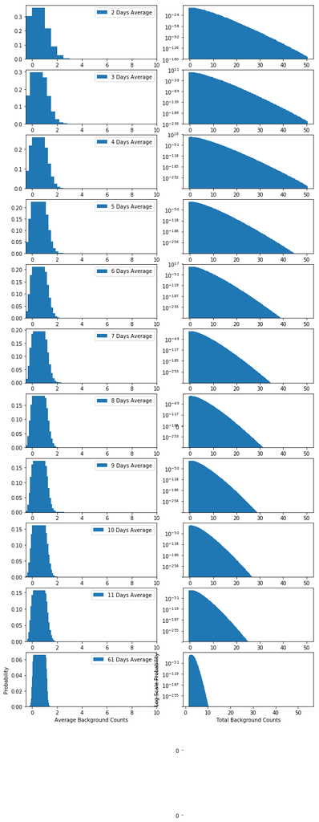

```python
fig, ax = plt.subplots(11,2,figsize=(10,25))
ppmf = ppmf1d

for i in np.arange(0,10):
    ppmf = np.convolve(ppmf,ppmf1d,mode ='full')
    ax[i][0].bar(np.arange(0,len(ppmf))/(i+2),ppmf,width=1,label = "{0:d} Days Average".format(i+2))
    ax[i][0].set_xlim(-.5,10)
    ax[i][0].set_xlabel("Average Background Counts Per Day")
    ax[i][0].legend()

    ax[i][1].bar(np.arange(0,len(ppmf))/(i+2),ppmf,width=1,label = "{0:d} Days Average".format(i+1))
    ax[i][1].set_yscale('log')

ppmf = ppmf1d
for j in np.arange(0,60):
    ppmf = np.convolve(ppmf1d,ppmf,'full')

ax[10][0].bar(np.arange(0,len(ppmf))/(61),ppmf,width =1, label = "61 Days Average")
ax[10][0].set_xlim(-.5,10)
ax[10][0].set_xlabel('Average Background Counts')
ax[10][0].set_ylabel('Probability');
ax[10][0].legend()

ax[10][1].bar(np.arange(0,len(ppmf))/j+2,ppmf,width =1)
ax[10][1].set_xlabel('Total Background Counts')
ax[10][1].set_ylabel('Log Scale Probability')
ax[10][1].set_yscale('log');
```

We can see that as we average over more and more days the distribution has a smaller and smaller spread of counts(visible in the Log plots). This makes sense from part B since we can see that as the sum of the means gets larger the larger average counts will become less and less probable. This makes sense with the Central Limit Theorem because as the sum gets infintely large the distribution will approach a normal distribution with a center at k = X = 0.6 in my case.(We can see this in the last graph with the upside down parabola starting to take shape)

### D).

I choose to use N = 61 for the number of days.

This makes it so Y * N = 122 gamma rays over the 61 days.

I will calculate the pmf for 61 days by convolving with itself 60 times. Then I will sum the probabilities of all the values in the array $\geq$ 122 counts. This will give me the probability of the 122 gamma rays occuring from just the background. I will then find the sigma value of these by looking at a guassian distribution and integrating from the right side until I get the probability and this will allow me to get my sigma value.

```python
#ppmf found in previous cell for 61 summed days and still initialized
probability = ppmf[122:len(ppmf):1].sum()
sigma= stats.norm.isf(probability)
print("There is a {0:.2f} sigma probability that my background would have had a count of 122 gamma rays over 61 days.".format(sigma))
```

```
There is a 11.06 sigma probability that my background would have had a count of 122 gamma rays over 61 days.
```

## Problem 2:

### A).

I chose the Rayleigh distribution. The Rayleigh distribution is a continuous probability distribution for nonnegative-valued random variables. It is essentially a chi distribution with two degrees of freedom.

$$ f(x;\sigma )={\frac {x}{\sigma ^{2}}}e^{-x^{2}/(2\sigma ^{2})},\quad x\geq 0 $$

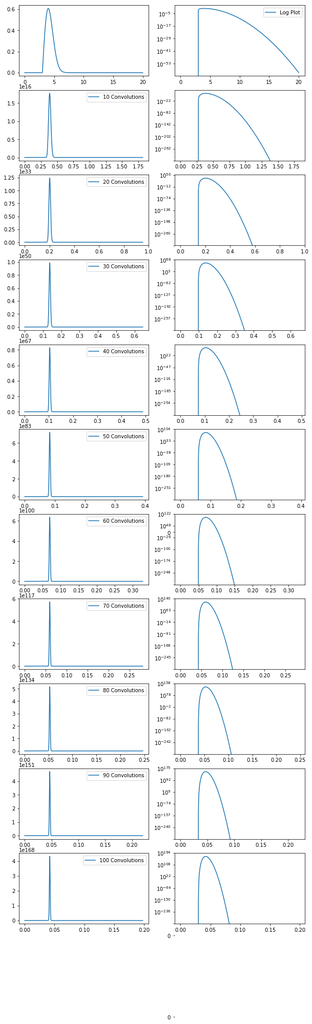

```python
x = np.linspace(0,20,1000)
raypdf = stats.rayleigh.pdf(x,loc=3)
raypdfc = raypdf
j=1
fig,ax = plt.subplots(11,2,figsize=(10,33))
ax[0][0].plot(x,raypdf)
ax[0][1].plot(x,raypdf,label = 'Log Plot')
ax[0][1].set_yscale('log')
ax[0][1].legend()

for i in np.arange(1,101):
    raypdfc = np.convolve(raypdfc,raypdf)

    if i%10 == 0:

        ax[j][0].plot(np.linspace(0,x.max(),len(raypdfc))/(i+1),raypdfc,label='{0:d} Convolutions'.format(i))
        ax[j][0].legend()
        ax[j][1].plot(np.linspace(0,x.max(),len(raypdfc))/(i+1),raypdfc,label='Log Plot')
        ax[j][1].set_yscale('log')
        ax[j][1].legend
        j += 1
```

### B).

The shape changes relatively quick as the spread becomes smaller and smaller with more convolutions. In the normal y plot it is apparent that after averaging the Rayleigh distribution the resulting distribution becomes more and more narrow. In the log of the y-axis plot we can see that after about 20 convolutions the distribution begins to tend towards that iconic upside parabola shape and then after 60 convolutions they trend begans reach a point where it doesn't change much after more convolutions.

## Problem 3:

### A).

Width of the Guassian distribution is X=2

Signal strength is Y = 11.3

The normal (or Gaussian) distribution is a very common continuous probability distribution. Normal distributions are important in statistics and are used to represent real-valued random variables whose distributions are not known.

$${\displaystyle f(x\mid \mu ,\sigma ^{2})={\frac {1}{\sqrt {2\pi \sigma ^{2}}}}e^{-{\frac {(x-\mu )^{2}}{2\sigma ^{2}}}}}$$

Where $\mu$ is the mean and $\sigma$ is the standard deviation from the mean.

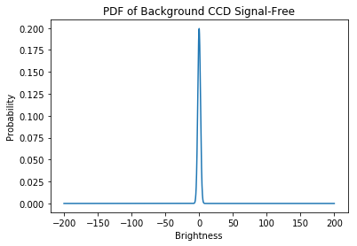

```python
x = np.linspace(-200,200,1000000)
width = 2
signal = 11.3

gpdf = stats.norm.pdf(x,scale =2)


plt.plot(x,gpdf)
plt.title('PDF of Background CCD Signal-Free')
plt.ylabel('Probability')
plt.xlabel('Brightness');
```

```python
probability = stats.norm.sf(11.3,scale=2)

sigma = stats.norm.isf(probability,scale=1)
sigma

print("The probability that our dectection of 11.3 brightness was caused by the background is {0}. This corresponds to a {1} Sigma. Thus we can claim discovery since it is over our 5 Sigma threshold.".format(probability,sigma))
```

```
The probability that our dectection of 11.3 brightness was caused by the background is 8.022391850663474e-09. This corresponds to a 5.650000000000001 Sigma. Thus we can claim discovery since it is over our 5 Sigma threshold.
```

### B).

Using the background distribution for one pixel from part A. After scanning through 10k pixels worth of data we have looked at 10k 1 pixel distributions. What is the probability distribution of our background and what is the probability our background produced a brightness of 11.3 when looking at the entire 10k pixels worth of data?

In essence we are summing the pdf 10k times and so it has moved up by a factor of 10k.

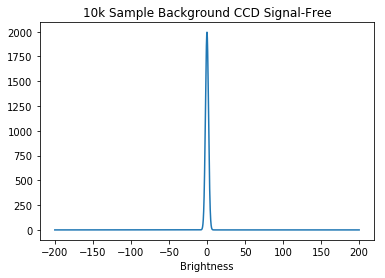

```python
gpdf = stats.norm.pdf(x,scale =2)
newgpdf = gpdf*10000

plt.plot(x,newgpdf)
plt.title('10k Sample Background CCD Signal-Free')
plt.xlabel('Brightness');
```

### C).

```python
newprobability = stats.norm.sf(11.3,scale=2)*10000

newsigma = stats.norm.isf(newprobability)

print("The probability that our dectection of 11.3 brightness was caused by the background from 10k pixels is {0}. This corresponds to a {1} sigma. Thus we can not claim discovery since it is below our 5 Sigma threshold.".format(newprobability,newsigma))
```

```
The probability that our dectection of 11.3 brightness was caused by the background from 10k pixels is 8.022391850663474e-05. This corresponds to a 3.7743151329859677 sigma. Thus we can not claim discovery since it is below our 5 Sigma threshold.
```

## Problem 4:

### A).

```python
# 5 sigma probability
sigma5prob = stats.norm.sf(5)

sigmav1 = stats.norm.isf(sigma5prob,scale=2)

print('In order to get a 5 Sigma probability of detection in Version 1 we would need to detect a brightness of {0:.1f}'.format(sigmav1))
```

```
In order to get a 5 Sigma probability of detection in Version 1 we would need to detect a brightness of 10.0
```

### B).

```python
trialsfactor = 10000
sigmav2 = stats.norm.isf(sigma5prob/trialsfactor,scale=2)

print('In order to get a 5 Sigma probability of detection in Version 2 we would need to detect a brightness of {0:.1f}'.format(sigmav2))
```

```
In order to get a 5 Sigma probability of detection in Version 2 we would need to detect a brightness of 13.1
```

### C).

The signal needs to be 31% larger or 1.31 times the value of the Version 1 $5 \sigma$ value in order to be signifigant to the probability of 5sigma. For Version 1 we get that the brightness needs to be at least 10 to be considered significant, but for Version 2 we need it to be 13.1 in order to be considered significant. This can be explained by our probability plots since once we get to large values of brightness the probability drops of very steeply (that -x^2 plot in the log view). This means that our trials number is low enough that it doesn't have a large effect on the far end of the distribution and doesn't end up contributing much to changing the probability of having a signal-free event at larger brightness numbers.

### D).

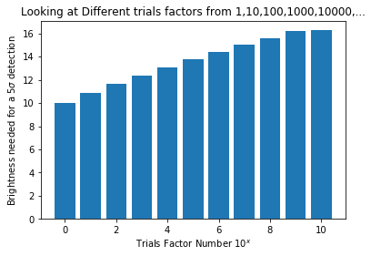

```python
ordersofmag = np.arange(0,11)
sigmasatdifferenttrials = stats.norm.isf(sigma5prob/(10**ordersofmag),scale=2)

plt.bar(ordersofmag,sigmasatdifferenttrials)
plt.ylabel(r'Brightness needed for a 5$\sigma$ detection')
plt.xlabel(r'Trials Factor Number $10^x$')
plt.title('Looking at Different trials factors from 1,10,100,1000,10000,...');
```